# Thesis

Luka Parisi

18 November, 2022

# Thesis regressions

## Importing packages and loading data

```r
library(tidyverse)
library(dplyr)
library(summarytools)
library(ggplot2)
library(coefplot)
library(did)
library(fixest)
library(modelsummary)
library(bacondecomp)
library(usmap)
library(fwildclusterboot)
```

```r
guns = read_csv('C:/Users/paris/OneDrive/Documents/ForR_controls.csv')
guns$...1 = NULL
guns$log_pop <- log(guns$pop_const)
```

## Graphical representation of treatment and control states

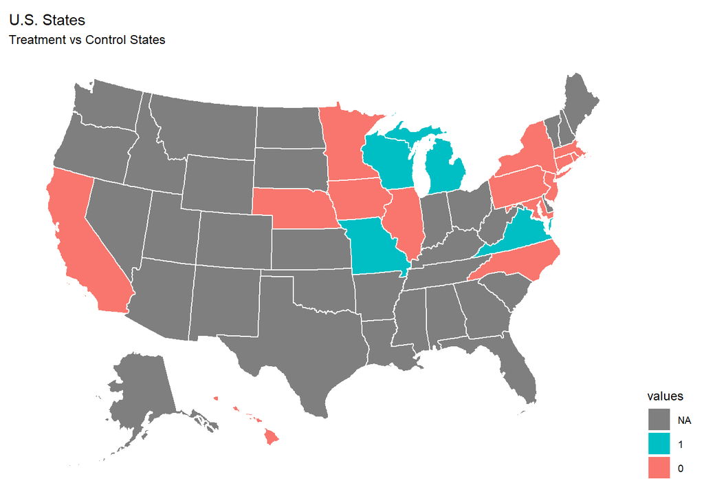

```r
map <- data.frame(guns$State,guns$treatment_group)
map$state <- map$guns.State
map$values <- map$guns.treatment_group
map$guns.scode <- NULL
map$guns.treatment_group <- NULL
map$values <- as.factor(map$values)

plot_usmap(regions = "states" , data = map,color = "white") +
  scale_fill_discrete(guide = guide_legend(reverse=TRUE)) +
  labs(title = "U.S. States",
       subtitle = "Treatment vs Control States") +
  theme(legend.position = "right")
```

## Descriptive statistics

```r
guns$bchecks_rate <- guns$bchecks/guns$population*100000
char <- c('treatment_group','population','waitingh','permith','delay','rate_calculated','rlong_guns','rate_other','fraction_wmale','BRFSS','per_rural','bchecks_rate','per_hsmore','med_earn','perc_binge')
datasummary_balance(~treatment_group, guns[,char],fmt = 2)
```

|  | 0 Mean | 0 Std. Dev. | 1 Mean | 1 Std. Dev. |
| --- | --- | --- | --- | --- |
| population | 9159701.92 | 9256883.63 | 7354891.77 | 1771725.90 |
| waitingh | 0.57 | 0.50 | 0.18 | 0.39 |
| permith | 0.86 | 0.35 | 0.31 | 0.46 |
| delay | 1.00 | 0.00 | 0.49 | 0.50 |
| rate_calculated | 3.42 | 1.67 | 5.40 | 1.66 |
| rlong_guns | 0.73 | 0.57 | 1.74 | 0.60 |
| rate_other | 6.22 | 1.60 | 6.09 | 1.04 |
| fraction_wmale | 0.36 | 0.08 | 0.39 | 0.03 |
| BRFSS | 0.26 | 0.13 | 0.41 | 0.02 |
| per_rural | 0.18 | 0.11 | 0.30 | 0.03 |
| bchecks_rate | 3841.08 | 4742.86 | 5140.28 | 2377.50 |
| per_hsmore | 0.88 | 0.03 | 0.88 | 0.01 |
| med_earn | 36862.00 | 4184.38 | 33755.00 | 3370.38 |
| perc_binge | 16.05 | 2.68 | 16.98 | 2.96 |

## Sanity check - What happened to background checks after law repeal?

Note: Background check data has yet to be cleaned!

```
## No summary function supplied, defaulting to `mean_se()`
```

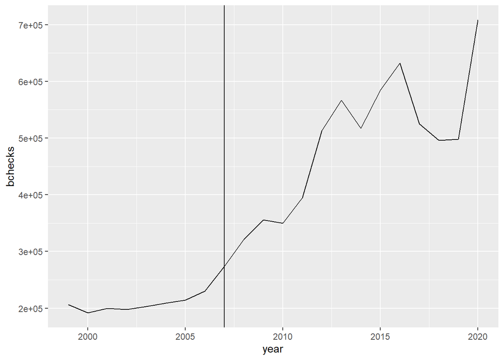

```r
ggplot(subset(guns,guns$State == 'Missouri'),aes(year,bchecks)) + stat_summary(geom = 'line') +  geom_vline(xintercept = 2007)
```

```
## No summary function supplied, defaulting to `mean_se()`
```

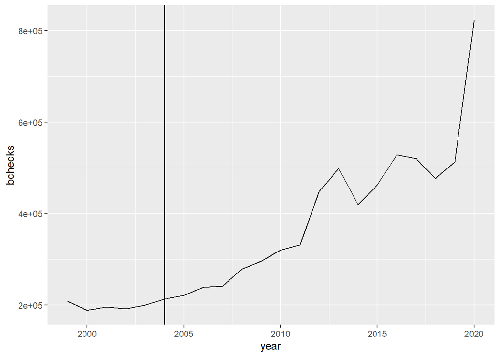

```r
ggplot(subset(guns,guns$State == 'Virginia'),aes(year,bchecks)) + stat_summary(geom = 'line') +  geom_vline(xintercept = 2004)
```

```
## No summary function supplied, defaulting to `mean_se()`
```

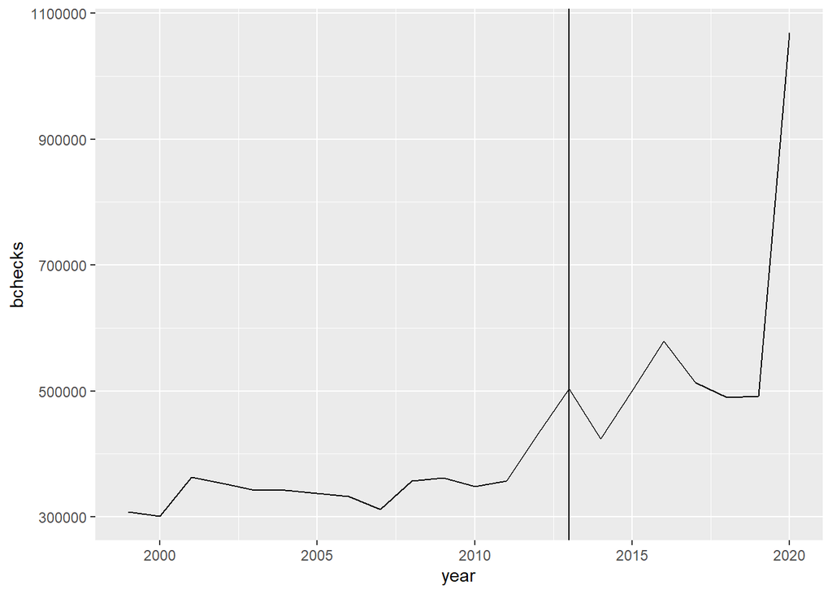

```r
ggplot(subset(guns,guns$State == 'Michigan'),aes(year,bchecks)) + stat_summary(geom = 'line') +  geom_vline(xintercept = 2013)
```

```
## No summary function supplied, defaulting to `mean_se()`
```

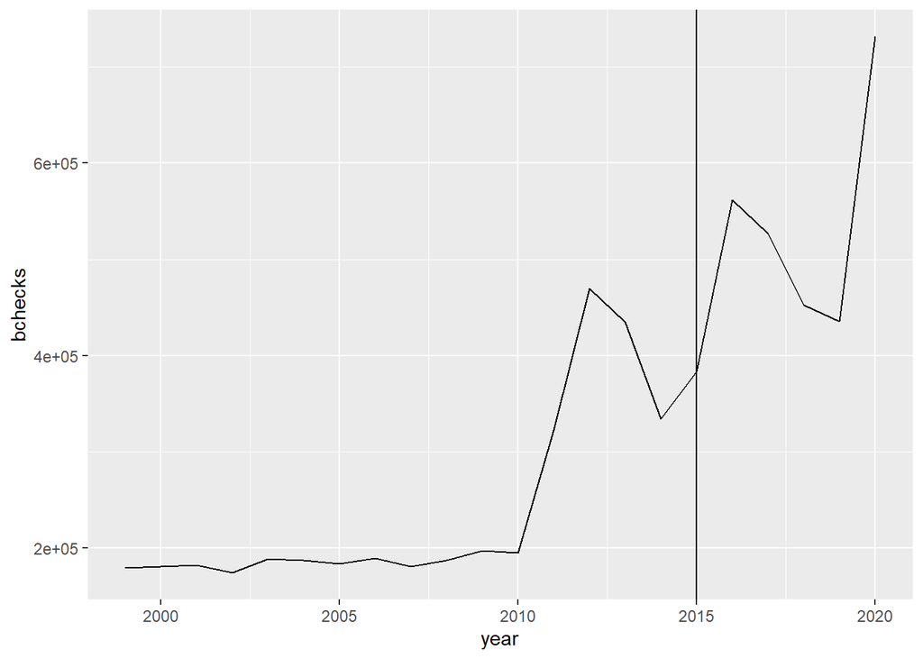

```r
ggplot(subset(guns,guns$State == 'Wisconsin'),aes(year,bchecks)) + stat_summary(geom = 'line') +  geom_vline(xintercept = 2015)
```

```r
twfe <- feols(log(bchecks/population) ~ treatment | scode + year,weights = ~population, data = guns)
msummary(twfe, stars = c('*' = .1, '**' = .05, '***' = .01))
```

|  | Model 1 |
| --- | --- |
| treatment | −0.015 |
|  | (0.119) |
| Num.Obs. | 396 |
| AIC | −159.8 |
| RMSE | 0.20 |
| Std.Errors | by: scode |
| FE: scode | X |
| FE: year | X |

* p < 0.1, ** p < 0.05, *** p < 0.01

# Start of relevant regressions

## ‘Naive’ TWFE and Bacon Decomposition

First I will run a naive TWFE model, controlling for state and year fixed effects. The first model will have clustered SE while the second will have wild cluster bootstrapped standard errors. These regressions have not been weighted by state population!

```r
naive <- feols(log_rate ~ treatment | scode + year, data = guns)
naive_boot <- boottest(naive, clustid = c("scode"), B = 9999, param = "treatment", seed = 1)
msummary(list('Clustered SE' = naive, 'Wild Cluster Bootstrap' = naive_boot),coef_rename = c('1*treatment = 0' = 'treatment'),estimate = "{estimate}", statistic = c("conf.int", "p = {p.value}"),
            gof_omit = 'R2 Pseudo|AIC|BIC|Log.Lik.|R2 Within|R2 Adj.')
```

|  | Clustered SE | Wild Cluster Bootstrap |
| --- | --- | --- |
| treatment | 0.184 | 0.184 |
|  | [0.041, 0.326] | [−0.023, 0.352] |
|  | p = 0.014 | p = 0.084 |
| Num.Obs. | 396 | 396 |
| R2 |  | 0.940 |
| RMSE | 0.12 |  |
| Std.Errors | by: scode |  |
| FE: scode | X |  |
| FE: year | X |  |

Now I will look at the Bacon decomposition of the naive TWFE model. I.e., how the cannonical 2x2 did has been weighted.

```r
df_bacon <- bacon(log_rate ~ treatment, data = guns,
                  id_var = 'scode',
                  time_var = 'year')
```

```
##                       type  weight  avg_est
## 1 Earlier vs Later Treated 0.04104 -0.02555
## 2 Later vs Earlier Treated 0.04635  0.08371
## 3     Treated vs Untreated 0.91260  0.19809
```

```r
coef_bacon <- sum(df_bacon$estimate * df_bacon$weight)
print(paste("Weighted sum of decomposition =", round(coef_bacon, 4)))
```

```
## [1] "Weighted sum of decomposition = 0.1836"
```

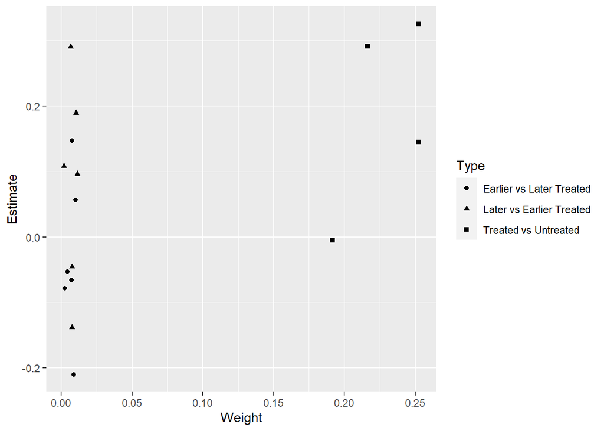

```r
ggplot(df_bacon) +
  aes(x = weight, y = estimate, shape = factor(type)) +
  labs(x = "Weight", y = "Estimate", shape = "Type") +
  geom_point()
```

As we can see, the “good” treatment effects have the highest weight. Im assuming that the estimate at 0.0 is Virginia.

## TWFE with population weights and controls

First I will run the basic TWFE model, but now with weights that are equal to the population of the year 2004. I need to check if this is the correct way to specify weights in feols (reminder). Finally, I will wild cluster bootstrap the standard errors for the coefficient of interest.

```r
twfe <- feols(log_rate ~ treatment | scode + year,weights = ~pop_const, data = guns)
twfe_boot <- boottest(twfe, clustid = "scode", B = 9999, param = "treatment", seed = 1000)
```

Furthermore, I will add two control variables: `per_rural` & `per_white` and interact them with year fixed effects. Again, wild-cluster standard errors will be used for the coefficient of interest.

```r
twfe_c <- feols(log_rate ~ treatment + per_rural*factor(year) + per_white*factor(year) | scode + year,
                weights = ~pop_const,data = guns)
```

```
## Variables 'per_rural', 'factor(year)2000' and 21 others have been removed because of collinearity (see $collin.var).
```

```r
twfec_boot <- boottest(twfe_c, clustid = c("scode"), B = 9999, param = "treatment", seed = 1)
```

Summary table omiting unnecessary variables and goodness of fit metrics:

```r
msummary(list('TWFE' = twfe_boot, 'TWFE Controls' = twfec_boot),
         coef_rename = c('1*treatment = 0' = 'Treatment'),
          estimate = "{estimate}", statistic = c("conf.int", "p = {p.value}"), stars = TRUE,
            gof_omit = 'R2 Pseudo|AIC|BIC|Log.Lik.|R2 Within|R2 Adj.')
```

|  | TWFE | TWFE Controls |
| --- | --- | --- |
| Treatment | 0.215 | 0.122 |
|  | [0.000, 0.483] | [−0.003, 0.296] |
|  | p = 0.050 | p = 0.053 |
| Num.Obs. | 396 | 396 |
| R2 | 0.962 | 0.976 |

+ p < 0.1, * p < 0.05, ** p < 0.01, *** p < 0.001

As can be seen, in the first regression without controls, repealing the policy leaded to an aprox. increase in handgun related suicides by 21.5% (need to use $(e^{a-1})*100\%$ to get correct % change). When adding the percentage of white population and percentage of people living in rural areas the estimate drops down to around 12.5%.

## Event-study; checking pre-trends

Here I run into problems because I cant seem to get the correct wild cluster bootstrap standard errors for event time estimates.

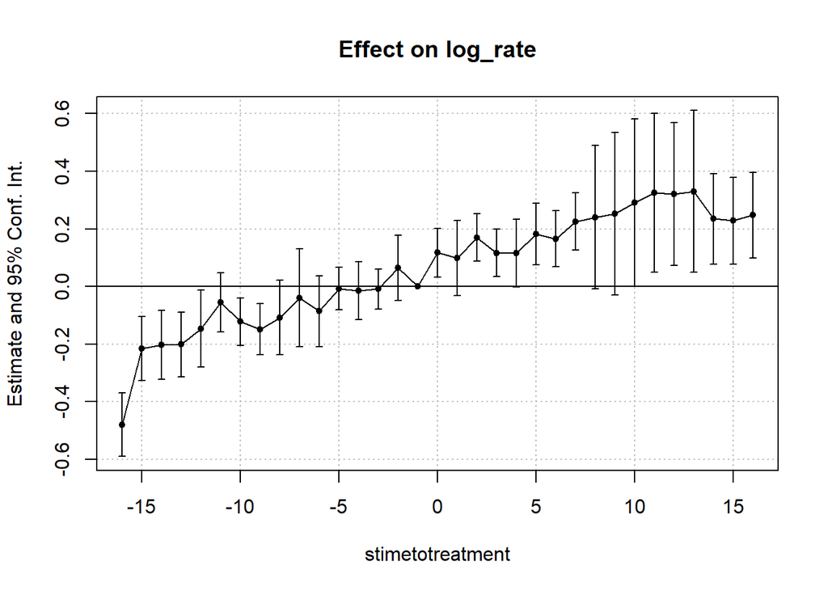

```r
pre_twfe = feols(log_rate ~ i(stimetotreatment, treatment_group, ref = -1) | scode + year, weights = ~pop_const, data = guns)
iplot(pre_twfe,pt.join = TRUE, ref = -1)
```

This is with clustered SE. Even though the confidence intervals are all around 0 in the few years leading to the repeal of the policy I find it troubling that there seems to be a linear upward trend throughout the whole time period. We will get back to this while using the Sant’Anna & Callaway model because strangly this linear trend dissapears when using their estimator.

Now, I will try to run a for loop which will bootstrap all of the estimates.

```r
coef_name <- names(coef(pre_twfe))
multiple_bootstraps <- lapply(coef_name, function(x){
     boottest(pre_twfe, param = x,clustid = c("scode"), B = 9999)
})
for (number in 1:32){print(multiple_bootstraps[[number]]$conf_int)}
```

```
## [1] -2.394869  0.709388
## [1] -2.3169961  0.8210945
## [1] -2.1348621  0.2718364
## [1] -1.9862210  0.1504592
## [1] -3.6569225  0.2281787
## [1] -1.7017654  0.3208966
## [1] -2.3479425  0.2442163
## [1] -1.90266457  0.04248492
## [1] -0.3485189  0.1453825
## [1] -4.9573094  0.3832874
## [1] -1.2973099  0.6124317
## [1] -0.7085486  0.6816314
## [1] -2.3456746  0.5112519
## [1] -0.6591885  0.5465815
## [1] -0.09500751  0.95003757
```

[output cut: 17 more lines]

I have to work on extracting the point estimates and confidence intervals into a new dataframe which I can later try to plot. However just from observing the confidence intrevals I can see that all the pre-treatment trends are statistically insignificant.

```r
mod_twfe = feols(log_rate ~ i(stimetotreatment, treatment_group, ref = -1)
                 + per_rural*factor(year) + per_white*factor(year) | scode + year,
                    weights = ~pop_const, data = guns)
```

```
## Variables 'per_rural', 'factor(year)2000' and 21 others have been removed because of collinearity (see $collin.var).
```

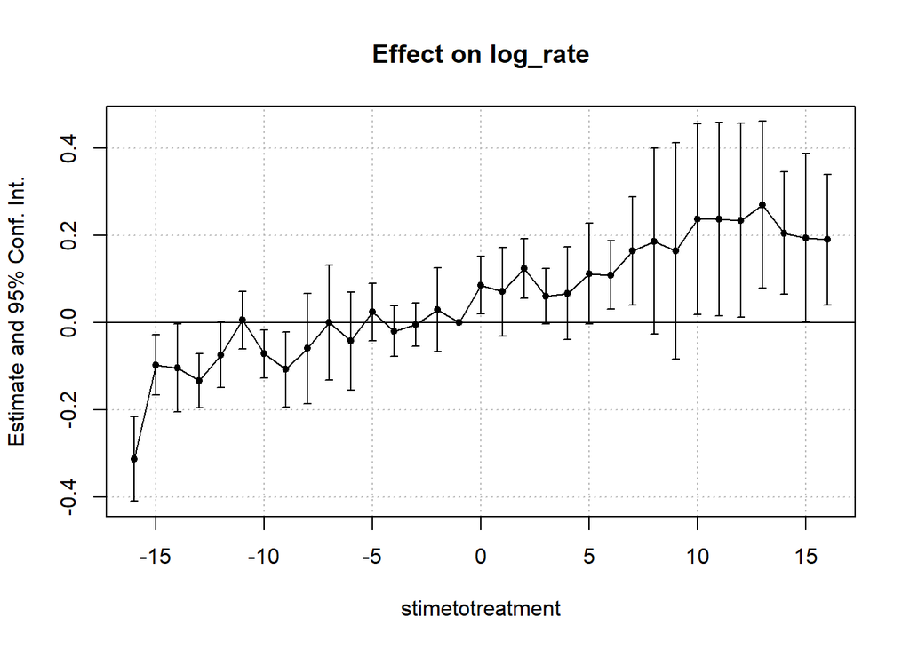

```r
iplot(mod_twfe,pt.join = TRUE, ref = -1)
```

Again, this is the graph with clustered SE. Same problem for wild cluster bootstrap holds as above. Will deal with this in the coming weeks. However we can see that the point estimates look better and there seems to be less of a linear trend.

Comparing the no controls vs controls:

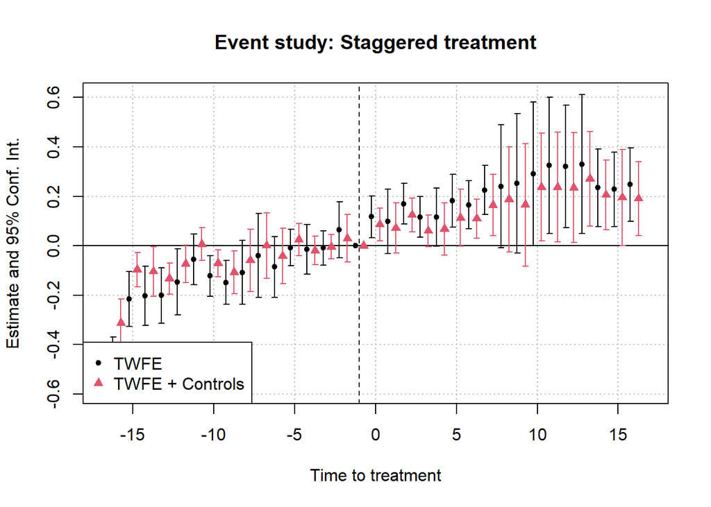

```r
iplot(list(pre_twfe, mod_twfe), sep = 0.5, ref.line = -1,
      xlab = 'Time to treatment',
      main = 'Event study: Staggered treatment')
legend("bottomleft", col = c(1, 2), pch = c(20, 17),
       legend = c("TWFE", "TWFE + Controls"))
```

# Santa’Anna & Callaway

## No controls & weighted by population

```r
out <- att_gt(yname = 'log_rate',
              gname = 'byear',
              idname = 'scode',
              tname = 'year',
              xformla = ~ 1,
              data = guns,
              est_method = "dr",
              weightsname = 'pop_const',
              control_group = 'nevertreated',
              bstrap = T,
              biters = 1000)
```

[output not shown]

[output cut: 112 more lines]

[output not shown]

```
## Warning in att_gt(yname = "log_rate", gname = "byear", idname = "scode", : Not
## returning pre-test Wald statistic due to singular covariance matrix
```

```r
es <- aggte(out, type = "dynamic")
summary(es)
```

```
##
## Call:
## aggte(MP = out, type = "dynamic")
##
## Reference: Callaway, Brantly and Pedro H.C. Sant'Anna.  "Difference-in-Differences with Multiple Time Periods." Journal of Econometrics, Vol. 225, No. 2, pp. 200-230, 2021. <https://doi.org/10.1016/j.jeconom.2020.12.001>, <https://arxiv.org/abs/1803.09015>
##
##
## Overall summary of ATT's based on event-study/dynamic aggregation:
##     ATT    Std. Error     [ 95%  Conf. Int.]
##  0.1872        0.0519     0.0855       0.289 *
##
##
## Dynamic Effects:
##  Event time Estimate Std. Error [95% Simult.  Conf. Band]
##         -15   0.2624     0.0262        0.2006      0.3241 *
##         -14  -0.0581     0.0294       -0.1274      0.0112
##         -13  -0.0006     0.0170       -0.0407      0.0394
##         -12   0.0506     0.0285       -0.0165      0.1177
##         -11   0.0924     0.0278        0.0268      0.1579 *
##         -10  -0.0733     0.0524       -0.1967      0.0501
##          -9  -0.0205     0.0435       -0.1230      0.0820
##          -8   0.0762     0.0524       -0.0472      0.1996
##          -7   0.0688     0.0517       -0.0530      0.1905
##          -6  -0.0476     0.0831       -0.2433      0.1481
##          -5   0.0168     0.0344       -0.0643      0.0978
##          -4  -0.0063     0.0421       -0.1054      0.0928
##          -3   0.0053     0.0259       -0.0558      0.0663
##          -2   0.0731     0.0458       -0.0348      0.1810
##          -1  -0.0682     0.0573       -0.2032      0.0667
##           0   0.1220     0.0490        0.0065      0.2374 *
##           1   0.1009     0.0746       -0.0747      0.2764
##           2   0.1783     0.0403        0.0835      0.2732 *
##           3   0.1259     0.0459        0.0178      0.2340 *
##           4   0.1179     0.0622       -0.0286      0.2644
##           5   0.1898     0.0474        0.0783      0.3013 *
##           6   0.1496     0.0403        0.0548      0.2445 *
##           7   0.2051     0.0342        0.1247      0.2855 *
##           8   0.1847     0.1028       -0.0573      0.4267
##           9   0.2044     0.1104       -0.0554      0.4643
##          10   0.2330     0.1177       -0.0442      0.5101
##          11   0.2787     0.1194       -0.0025      0.5599
##          12   0.2792     0.0993        0.0453      0.5131 *
##          13   0.2801     0.1133        0.0134      0.5469 *
##          14   0.1755     0.0572        0.0407      0.3103 *
##          15   0.1706     0.0623        0.0240      0.3172 *
##          16   0.1870     0.0678        0.0274      0.3465 *
## ---
## Signif. codes: `*' confidence band does not cover 0
##
## Control Group:  Never Treated,  Anticipation Periods:  0
## Estimation Method:  Doubly Robust
```

These are the event study coefficients. We can see that only 2 pre-treatment coefficients are stat. significant. Since they are -11 and -15 I am not troubled because at the bin of the distribution there is a smaller number of obs. Important note, standard errors are generated through a multiplier bootstrap method they talk about in their paper. Finally, I have weighted the regression by state population. However, I get the following error message: `Warning: glm.fit: fitted probabilities numerically 0 or 1.`. I do not know what this means, but my results are generated without problems.

Lets look at this graphically.

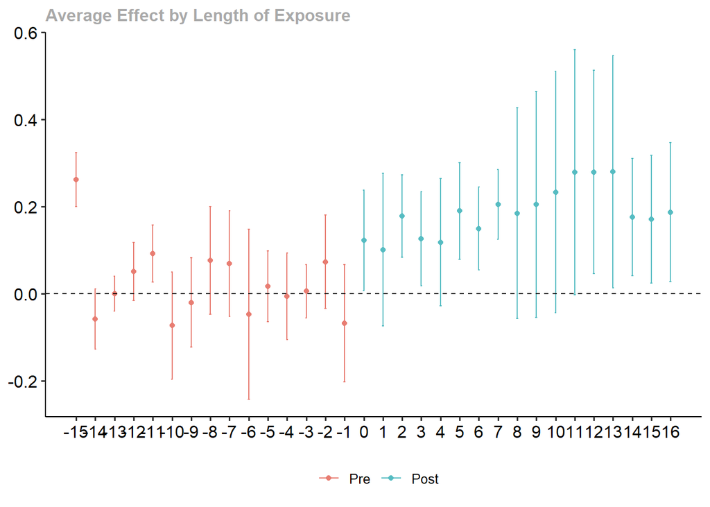

```r
ggdid(es)
```

```r
group_effects <- aggte(out, type = "group")
summary(group_effects)
```

```
##
## Call:
## aggte(MP = out, type = "group")
##
## Reference: Callaway, Brantly and Pedro H.C. Sant'Anna.  "Difference-in-Differences with Multiple Time Periods." Journal of Econometrics, Vol. 225, No. 2, pp. 200-230, 2021. <https://doi.org/10.1016/j.jeconom.2020.12.001>, <https://arxiv.org/abs/1803.09015>
##
##
## Overall summary of ATT's based on group/cohort aggregation:
##     ATT    Std. Error     [ 95%  Conf. Int.]
##  0.1895         0.027     0.1366      0.2424 *
##
##
## Group Effects:
##  Group Estimate Std. Error [95% Simult.  Conf. Band]
##   2004   0.1115     0.0423        0.0237      0.1993 *
##   2007   0.2300     0.0279        0.1722      0.2878 *
##   2013   0.1540     0.0325        0.0866      0.2214 *
##   2015   0.3177     0.0189        0.2786      0.3569 *
## ---
## Signif. codes: `*' confidence band does not cover 0
##
## Control Group:  Never Treated,  Anticipation Periods:  0
## Estimation Method:  Doubly Robust
```

As we can see, when weighted with state population I get huge estimates for every state out of which all are stat. significant. I will also show the results below if I dont put any weightage.

## Controls & weighted by population

```r
out1 <- att_gt(yname = 'log_rate',
              gname = 'byear',
              idname = 'scode',
              tname = 'year',
              xformla = ~ per_white + per_rural,
              data = guns,
              weightsname = 'pop_const',
              control_group = 'nevertreated',
              bstrap = T,
              biters = 1000)
```

[output not shown]

[output cut: 112 more lines]

[output not shown]

Again I am using the same control variables as in every regression until now.

```r
es1 <- aggte(out1, type = "dynamic")
summary(es1)
```

```
##
## Call:
## aggte(MP = out1, type = "dynamic")
##
## Reference: Callaway, Brantly and Pedro H.C. Sant'Anna.  "Difference-in-Differences with Multiple Time Periods." Journal of Econometrics, Vol. 225, No. 2, pp. 200-230, 2021. <https://doi.org/10.1016/j.jeconom.2020.12.001>, <https://arxiv.org/abs/1803.09015>
##
##
## Overall summary of ATT's based on event-study/dynamic aggregation:
##     ATT    Std. Error     [ 95%  Conf. Int.]
##  0.1425        0.0475     0.0493      0.2357 *
##
##
## Dynamic Effects:
##  Event time Estimate Std. Error [95% Simult.  Conf. Band]
##         -15   0.1832     0.0574        0.0513      0.3152 *
##         -14  -0.0942     0.0546       -0.2195      0.0312
##         -13  -0.0405     0.0453       -0.1447      0.0636
##         -12   0.0487     0.0305       -0.0213      0.1187
##         -11   0.0907     0.0349        0.0106      0.1709 *
##         -10  -0.0943     0.0258       -0.1537     -0.0350 *
##          -9  -0.0165     0.0354       -0.0978      0.0648
##          -8   0.0628     0.1006       -0.1682      0.2939
##          -7   0.0545     0.0968       -0.1679      0.2769
##          -6  -0.0283     0.0521       -0.1481      0.0914
##          -5   0.0032     0.0468       -0.1043      0.1107
##          -4  -0.0461     0.0577       -0.1786      0.0863
##          -3   0.0143     0.0333       -0.0623      0.0910
##          -2   0.0242     0.0406       -0.0691      0.1176
##          -1  -0.0250     0.0499       -0.1396      0.0897
##           0   0.0963     0.0488       -0.0157      0.2083
##           1   0.0701     0.0676       -0.0853      0.2254
##           2   0.1388     0.0369        0.0540      0.2237 *
##           3   0.0841     0.0275        0.0209      0.1473 *
##           4   0.0683     0.0592       -0.0678      0.2043
##           5   0.1218     0.0487        0.0099      0.2337 *
##           6   0.0994     0.0309        0.0284      0.1703 *
##           7   0.1396     0.0464        0.0330      0.2463 *
##           8   0.1561     0.0961       -0.0648      0.3770
##           9   0.1393     0.1209       -0.1385      0.4171
##          10   0.1916     0.0877       -0.0098      0.3930
##          11   0.2129     0.0820        0.0246      0.4012 *
##          12   0.2225     0.1047       -0.0180      0.4631
##          13   0.2323     0.0776        0.0540      0.4106 *
##          14   0.1593     0.0399        0.0676      0.2510 *
##          15   0.1540     0.0951       -0.0645      0.3725
##          16   0.1361     0.0611       -0.0041      0.2764
## ---
## Signif. codes: `*' confidence band does not cover 0
##
## Control Group:  Never Treated,  Anticipation Periods:  0
## Estimation Method:  Doubly Robust
```

We can see that the ATT has gone down. However it is still stat significant. Lets look at the event plot.

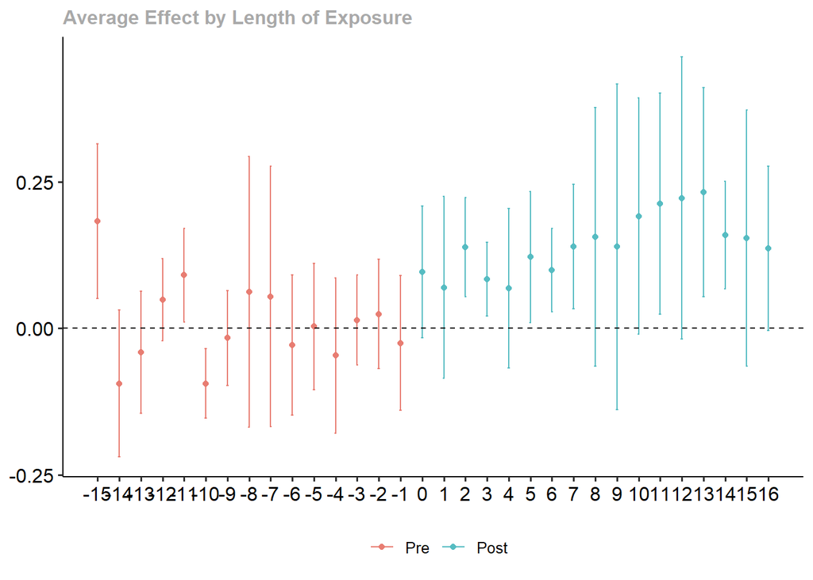

```r
ggdid(es1)
```

It seems like the control variables did not help with the stat. significant estimates in the pre-trend. Again these are 15-10 years before the policy repeal. I dont think I should be worried. What is good is that the increasing linear trend from the TWFE event study seems to have dissapeared.

```r
group_effects1 <- aggte(out1, type = "group")
summary(group_effects1)
```

```
##
## Call:
## aggte(MP = out1, type = "group")
##
## Reference: Callaway, Brantly and Pedro H.C. Sant'Anna.  "Difference-in-Differences with Multiple Time Periods." Journal of Econometrics, Vol. 225, No. 2, pp. 200-230, 2021. <https://doi.org/10.1016/j.jeconom.2020.12.001>, <https://arxiv.org/abs/1803.09015>
##
##
## Overall summary of ATT's based on group/cohort aggregation:
##     ATT    Std. Error     [ 95%  Conf. Int.]
##  0.1361        0.0324     0.0725      0.1996 *
##
##
## Group Effects:
##  Group Estimate Std. Error [95% Simult.  Conf. Band]
##   2004   0.0802     0.0336        0.0096      0.1508 *
##   2007   0.1976     0.0615        0.0683      0.3270 *
##   2013   0.0839     0.0370        0.0061      0.1617 *
##   2015   0.2430     0.0383        0.1624      0.3235 *
## ---
## Signif. codes: `*' confidence band does not cover 0
##
## Control Group:  Never Treated,  Anticipation Periods:  0
## Estimation Method:  Doubly Robust
```

We can see that the estimates are now more conservative. However every group is still stat significant and positive.

# Placebo tests - Do we find something we shouldnt & is there some form of substition going on?

I will now run two different TWFE models. I will change the dependent variable to be all other forms of suicide (without codes X72,X73,X74 -> i.e., no firearms included) and only long-gun related suicides. Small note, since the long-gun rates are suppressed for many states I downloaded the combination of codes X72-X74 and then calculated $X72+X74+X73 - X72-X74$ to get the true incidence of long-gun related suicides (X73). Furthermore, these values are sometimes below 1, making it impractical to use the natural log. To surpass this problem I added 1 to every row such that I can use the natural log.

```r
twfe_placebo <- feols(log_other ~ treatment | scode + year, weights = ~pop_const, data = guns)
twfep_boot <- boottest(twfe_placebo, clustid = c("scode"), B = 9999, param = "treatment", seed = 1)
twfe_long <- feols(log_long ~ treatment | scode + year, weights = ~pop_const,data = guns)
twfel_boot <- boottest(twfe_long, clustid = c("scode"), B = 9999, param = "treatment", seed = 1)
```

```r
msummary(list('All other' = twfep_boot, 'Long guns' = twfel_boot),
         coef_rename = c('1*treatment = 0' = 'Treatment'),
          estimate = "{estimate}", statistic = c("conf.int", "p = {p.value}"), stars = TRUE,
            gof_omit = 'R2 Pseudo|AIC|BIC|Log.Lik.|R2 Within|R2 Adj.')
```

|  | All other | Long guns |
| --- | --- | --- |
| Treatment | −0.024 | −0.050 |
|  | [−0.072, 0.023] | [−0.292, 0.122] |
|  | p = 0.160 | p = 0.591 |
| Num.Obs. | 396 | 396 |
| R2 | 0.901 | 0.914 |

+ p < 0.1, * p < 0.05, ** p < 0.01, *** p < 0.001

As we can see from the regression results, coeficients are negative.The negative point estimate makes sense, it basically says that on average people commit suicide less with other methods once a handgun purchase delay law is repealed. It is assuring that I do not find a statistically significant coefficient.

# Conclusion

To conclude, I can see that there is evidence of a positive hike in handgun-related suicides after the repeal of restrictive firearm purchase policies. There is still a lot of work to be done on this research question but the preliminary findings are reassuring. The biggest problem I have is wildcluster bootstraping the event study estimates and understanding if I am facing any problems with pre-trends!

## Additional Santa’Anna & Callaway regression without population weighting

```r
out3 <- att_gt(yname = 'log_rate',
              gname = 'byear',
              idname = 'scode',
              tname = 'year',
              xformla = ~ 1,
              data = guns,
              est_method = "dr",
              control_group = 'nevertreated',
              bstrap = T,
              biters = 1000)
es3 <- aggte(out3, type = "dynamic")
summary(es3)
```

```
##
## Call:
## aggte(MP = out3, type = "dynamic")
##
## Reference: Callaway, Brantly and Pedro H.C. Sant'Anna.  "Difference-in-Differences with Multiple Time Periods." Journal of Econometrics, Vol. 225, No. 2, pp. 200-230, 2021. <https://doi.org/10.1016/j.jeconom.2020.12.001>, <https://arxiv.org/abs/1803.09015>
##
##
## Overall summary of ATT's based on event-study/dynamic aggregation:
##     ATT    Std. Error     [ 95%  Conf. Int.]
##  0.1362        0.0657     0.0076      0.2649 *
##
##
## Dynamic Effects:
##  Event time Estimate Std. Error [95% Simult.  Conf. Band]
##         -15   0.2619     0.0629        0.1116      0.4123 *
##         -14  -0.0522     0.0290       -0.1214      0.0171
##         -13   0.0138     0.0295       -0.0565      0.0842
##         -12   0.0488     0.0337       -0.0317      0.1293
##         -11   0.0879     0.0316        0.0125      0.1634 *
##         -10  -0.0390     0.0662       -0.1970      0.1190
##          -9  -0.0652     0.0556       -0.1979      0.0676
##          -8   0.1156     0.0553       -0.0165      0.2477
##          -7   0.0298     0.0651       -0.1256      0.1852
##          -6  -0.0125     0.0573       -0.1494      0.1244
##          -5  -0.0007     0.0524       -0.1258      0.1244
##          -4  -0.0118     0.0372       -0.1008      0.0771
##          -3  -0.0156     0.0224       -0.0690      0.0378
##          -2   0.1197     0.0626       -0.0297      0.2690
##          -1  -0.0833     0.0760       -0.2648      0.0983
##           0   0.1158     0.0501       -0.0039      0.2355
##           1   0.0941     0.0914       -0.1241      0.3123
##           2   0.1454     0.0585        0.0058      0.2851 *
##           3   0.0991     0.0539       -0.0296      0.2278
##           4   0.0968     0.0657       -0.0601      0.2536
##           5   0.1565     0.0708       -0.0127      0.3257
##           6   0.0897     0.0682       -0.0730      0.2525
##           7   0.1743     0.0469        0.0622      0.2863 *
##           8   0.1327     0.1231       -0.1612      0.4266
##           9   0.1693     0.1132       -0.1010      0.4396
##          10   0.1934     0.1311       -0.1197      0.5066
##          11   0.2267     0.1356       -0.0972      0.5506
##          12   0.1977     0.1008       -0.0431      0.4384
##          13   0.2154     0.1263       -0.0862      0.5169
##          14   0.0978     0.0487       -0.0186      0.2141
##          15   0.0322     0.0827       -0.1653      0.2297
##          16   0.0794     0.0791       -0.1094      0.2682
## ---
## Signif. codes: `*' confidence band does not cover 0
##
## Control Group:  Never Treated,  Anticipation Periods:  0
## Estimation Method:  Doubly Robust
```

ATT is smaller by 5 percentage points. However, still stat. significant.

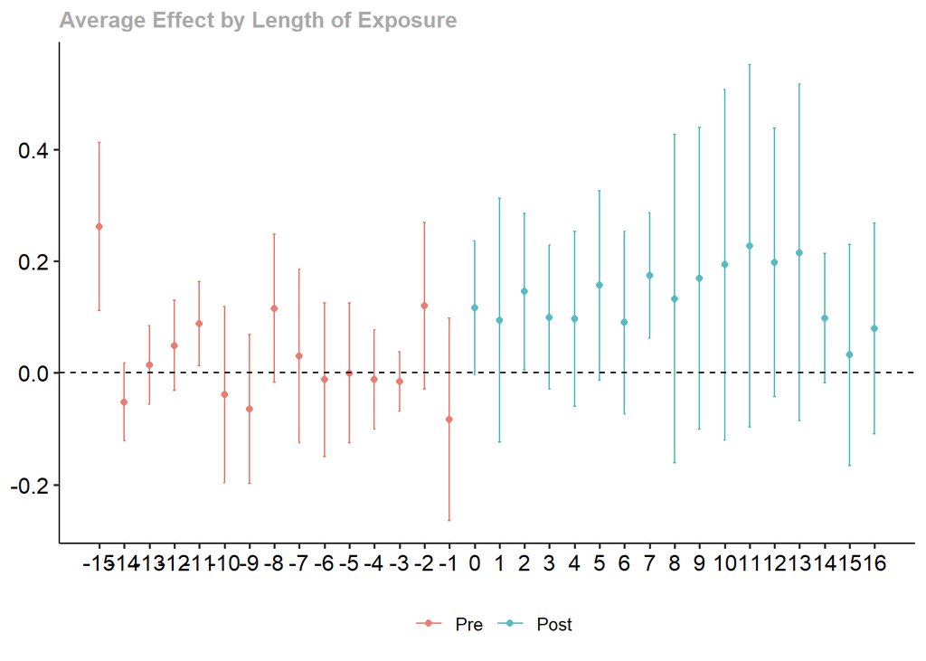

```r
ggdid(es3)
```

```r
group_effects3 <- aggte(out3, type = "group")
summary(group_effects3)
```

```
##
## Call:
## aggte(MP = out3, type = "group")
##
## Reference: Callaway, Brantly and Pedro H.C. Sant'Anna.  "Difference-in-Differences with Multiple Time Periods." Journal of Econometrics, Vol. 225, No. 2, pp. 200-230, 2021. <https://doi.org/10.1016/j.jeconom.2020.12.001>, <https://arxiv.org/abs/1803.09015>
##
##
## Overall summary of ATT's based on group/cohort aggregation:
##     ATT    Std. Error     [ 95%  Conf. Int.]
##  0.1607        0.0305      0.101      0.2204 *
##
##
## Group Effects:
##  Group Estimate Std. Error [95% Simult.  Conf. Band]
##   2004   0.0382     0.0663       -0.1013      0.1778
##   2007   0.1938     0.0454        0.0982      0.2893 *
##   2013   0.1371     0.0466        0.0389      0.2354 *
##   2015   0.2738     0.0442        0.1806      0.3670 *
## ---
## Signif. codes: `*' confidence band does not cover 0
##
## Control Group:  Never Treated,  Anticipation Periods:  0
## Estimation Method:  Doubly Robust
```

We can see that without population weighing Virginia still has a positive estimate but becomes stat. insignificant.

## Controls

```r
out4 <- att_gt(yname = 'log_rate',
              gname = 'byear',
              idname = 'scode',
              tname = 'year',
              xformla = ~ per_white + per_rural,
              data = guns,
              control_group = 'nevertreated',
              bstrap = T,
              biters = 1000)
es4 <- aggte(out4, type = "dynamic")
summary(es4)
```

```
##
## Call:
## aggte(MP = out4, type = "dynamic")
##
## Reference: Callaway, Brantly and Pedro H.C. Sant'Anna.  "Difference-in-Differences with Multiple Time Periods." Journal of Econometrics, Vol. 225, No. 2, pp. 200-230, 2021. <https://doi.org/10.1016/j.jeconom.2020.12.001>, <https://arxiv.org/abs/1803.09015>
##
##
## Overall summary of ATT's based on event-study/dynamic aggregation:
##     ATT    Std. Error     [ 95%  Conf. Int.]
##  0.0923         0.034     0.0256       0.159 *
##
##
## Dynamic Effects:
##  Event time Estimate Std. Error [95% Simult.  Conf. Band]
##         -15   0.1311     0.0219        0.0809      0.1812 *
##         -14  -0.0567     0.0223       -0.1077     -0.0057 *
##         -13   0.0077     0.0707       -0.1541      0.1696
##         -12  -0.0154     0.1020       -0.2491      0.2182
##         -11   0.1784     0.0370        0.0937      0.2632 *
##         -10  -0.0982     0.0396       -0.1889     -0.0076 *
##          -9   0.0226     0.0183       -0.0194      0.0645
##          -8   0.0950     0.0695       -0.0642      0.2541
##          -7  -0.0195     0.0919       -0.2300      0.1909
##          -6   0.0038     0.0532       -0.1181      0.1257
##          -5  -0.0022     0.0738       -0.1711      0.1668
##          -4  -0.0692     0.0467       -0.1760      0.0377
##          -3   0.0298     0.0316       -0.0425      0.1021
##          -2   0.0294     0.0203       -0.0172      0.0760
##          -1  -0.0288     0.0657       -0.1793      0.1218
##           0   0.0813     0.0319        0.0083      0.1544 *
##           1   0.0509     0.0626       -0.0926      0.1943
##           2   0.1147     0.0335        0.0380      0.1914 *
##           3   0.0564     0.0257       -0.0026      0.1153
##           4   0.0335     0.0349       -0.0465      0.1134
##           5   0.0776     0.0279        0.0137      0.1415 *
##           6   0.0082     0.0337       -0.0690      0.0855
##           7   0.0971     0.0349        0.0172      0.1770 *
##           8   0.0901     0.0634       -0.0552      0.2353
##           9   0.1013     0.0759       -0.0725      0.2752
##          10   0.1442     0.0672       -0.0098      0.2982
##          11   0.1384     0.0663       -0.0135      0.2903
##          12   0.1304     0.0566        0.0007      0.2601 *
##          13   0.1319     0.0565        0.0026      0.2612 *
##          14   0.1286     0.0333        0.0523      0.2048 *
##          15   0.0845     0.0825       -0.1043      0.2734
##          16   0.0995     0.0584       -0.0341      0.2332
## ---
## Signif. codes: `*' confidence band does not cover 0
##
## Control Group:  Never Treated,  Anticipation Periods:  0
## Estimation Method:  Doubly Robust
```

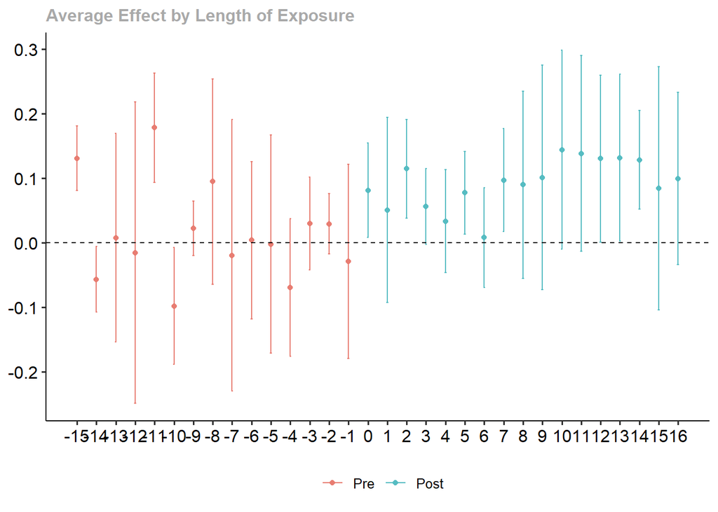

```r
ggdid(es4)
```

```r
group_effects4 <- aggte(out4, type = "group")
summary(group_effects4)
```

```
##
## Call:
## aggte(MP = out4, type = "group")
##
## Reference: Callaway, Brantly and Pedro H.C. Sant'Anna.  "Difference-in-Differences with Multiple Time Periods." Journal of Econometrics, Vol. 225, No. 2, pp. 200-230, 2021. <https://doi.org/10.1016/j.jeconom.2020.12.001>, <https://arxiv.org/abs/1803.09015>
##
##
## Overall summary of ATT's based on group/cohort aggregation:
##     ATT    Std. Error     [ 95%  Conf. Int.]
##  0.0907        0.0246     0.0426      0.1389 *
##
##
## Group Effects:
##  Group Estimate Std. Error [95% Simult.  Conf. Band]
##   2004   0.0651     0.0179        0.0274      0.1027 *
##   2007   0.0969     0.0532       -0.0148      0.2086
##   2013   0.0450     0.0371       -0.0329      0.1229
##   2015   0.1559     0.0253        0.1027      0.2092 *
## ---
## Signif. codes: `*' confidence band does not cover 0
##
## Control Group:  Never Treated,  Anticipation Periods:  0
## Estimation Method:  Doubly Robust
```